# GGPlot2

Shayne O’Brien

January 17, 2019

```r
library(tidyr)
library(ggplot2)
library(dplyr)
library(DT)
library(leaflet)
```

# Data Tidying

Read in data from Alaska Department of Fish and Game, Division of Commercial Fisheries. 2017. Daily salmon escapement counts from the OceanAK database, Alaska, 1921-2017. Knowledge Network for Biocomplexity. doi:10.5063/F1S46Q6M.

```r
esc <- read.csv("https://knb.ecoinformatics.org/knb/d1/mn/v2/object/urn%3Auuid%3Af119a05b-bbe7-4aea-93c6-85434dcb1c5e", stringsAsFactors = FALSE)
```

OR

```r
esc <- read.csv(url("https://knb.ecoinformatics.org/knb/d1/mn/v2/object/urn%3Auuid%3Af119a05b-bbe7-4aea-93c6-85434dcb1c5e", method = "libcurl"),  stringsAsFactors = FALSE)
```

`stringsAsFactors` R can deal with text more efficiently using this. Assigns a numeric value to each element. `echo = False, results = False` will allow you to run early analysis in RMarkdown but not have it appear in final project.

```r
head(esc)
```

```
##        Location SASAP.Region sampleDate Species DailyCount  Method
## 1 Akalura Creek       Kodiak 1930-05-24 Sockeye          4 Unknown
## 2 Akalura Creek       Kodiak 1930-05-25 Sockeye         10 Unknown
## 3 Akalura Creek       Kodiak 1930-05-26 Sockeye          0 Unknown
## 4 Akalura Creek       Kodiak 1930-05-27 Sockeye          0 Unknown
## 5 Akalura Creek       Kodiak 1930-05-28 Sockeye          0 Unknown
## 6 Akalura Creek       Kodiak 1930-05-29 Sockeye          0 Unknown
##   Latitude Longitude Source
## 1  57.1641 -154.2287   ADFG
## 2  57.1641 -154.2287   ADFG
## 3  57.1641 -154.2287   ADFG
## 4  57.1641 -154.2287   ADFG
## 5  57.1641 -154.2287   ADFG
## 6  57.1641 -154.2287   ADFG
```

*`separate` the date into year - month - day* `group_by` `summarize` to calculate the sum over unique region - year - species combinations *`filter` for salmos species

```r
annual_esc <- esc %>%
  separate(sampleDate, into = c("year", "month", "day"), sep = "-") %>%
  mutate(year = as.numeric(year)) %>%
  group_by(SASAP.Region, Species, year) %>%
  summarise(escapement = sum(DailyCount)) %>%
  filter(Species %in% c("Chinook", "Sockeye", "Pink", "Chum", "Coho"))

head (annual_esc)
```

```
## # A tibble: 6 x 4
## # Groups:   SASAP.Region, Species [1]
##   SASAP.Region                          Species  year escapement
##   <chr>                                 <chr>   <dbl>      <int>
## 1 Alaska Peninsula and Aleutian Islands Chinook  1974       1092
## 2 Alaska Peninsula and Aleutian Islands Chinook  1975       1917
## 3 Alaska Peninsula and Aleutian Islands Chinook  1976       3045
## 4 Alaska Peninsula and Aleutian Islands Chinook  1977       4844
## 5 Alaska Peninsula and Aleutian Islands Chinook  1978       3901
## 6 Alaska Peninsula and Aleutian Islands Chinook  1979      10463
```

```r
datatable(annual_esc)
```

|  | SASAP.Region | Species | year | escapement |
| --- | --- | --- | --- | --- |
| 1 | Alaska Peninsula and Aleutian Islands | Chinook | 1974 | 1092 |
| 2 | Alaska Peninsula and Aleutian Islands | Chinook | 1975 | 1917 |
| 3 | Alaska Peninsula and Aleutian Islands | Chinook | 1976 | 3045 |
| 4 | Alaska Peninsula and Aleutian Islands | Chinook | 1977 | 4844 |
| 5 | Alaska Peninsula and Aleutian Islands | Chinook | 1978 | 3901 |
| 6 | Alaska Peninsula and Aleutian Islands | Chinook | 1979 | 10463 |
| 7 | Alaska Peninsula and Aleutian Islands | Chinook | 1980 | 4506 |
| 8 | Alaska Peninsula and Aleutian Islands | Chinook | 1981 | 5046 |
| 9 | Alaska Peninsula and Aleutian Islands | Chinook | 1982 | 6503 |
| 10 | Alaska Peninsula and Aleutian Islands | Chinook | 1983 | 11589 |

[output cut: 1474 more lines]

# Static Plots w/ ggplot

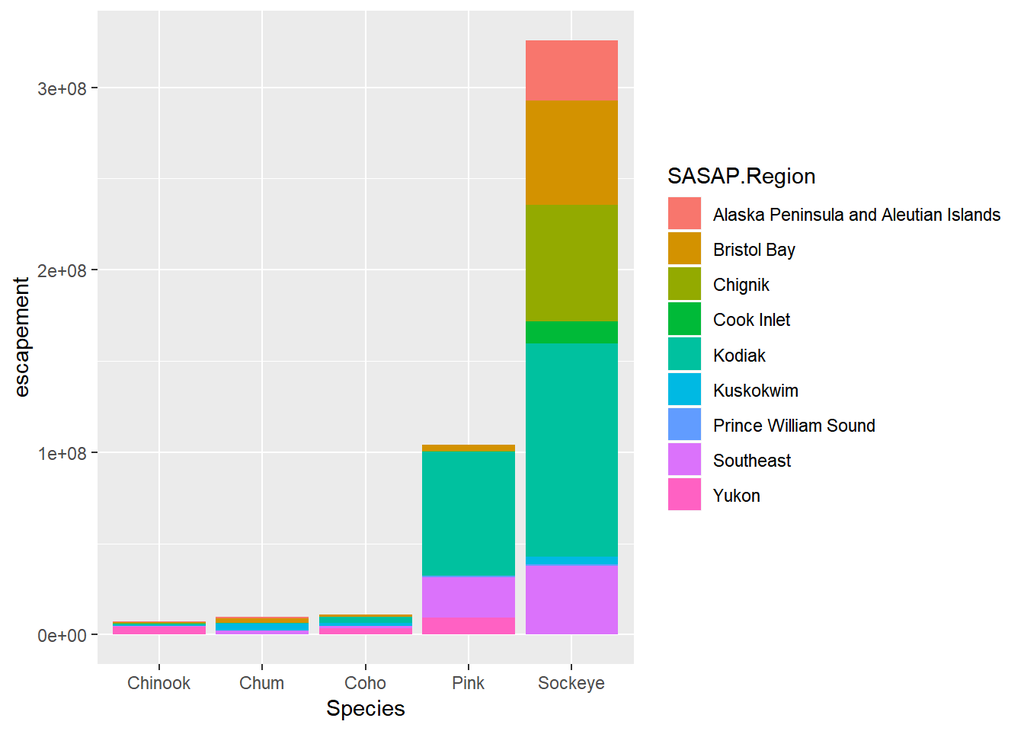

```r
ggplot(data = annual_esc, mapping = aes(x = Species, y = escapement, fill = SASAP.Region)) +
  geom_col() #This is the geometry
```

- ggplot requires adding the geometry of the plot in order for data to populate +`ggplot(data = annual_esc, mapping = aes(x = Species, y = escapement))` `+` `eom_col()`
- Color cant be in the `aes` or aesthetic call, it needs to be inside the `geom` call. +`geom_col(fill = "blue")`
- add fill to the `aes` attached to a variable to creat colored data entries +`ggplot(data = annual_esc, mapping = aes(x = Species, y = escapement, fill = Species))`
- If anything rund but is missing from the plot, be sure objects are added to the plot with `+`

Timeseries of Kodiak Escapement by Species

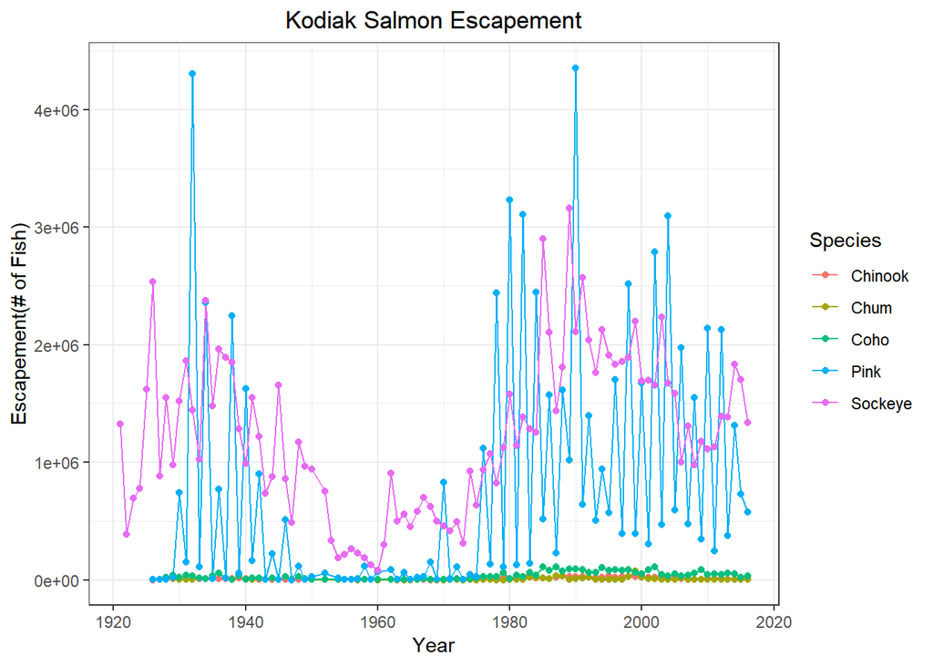

```r
ggplot(data = filter(annual_esc, SASAP.Region == "Kodiak"),
       aes(x = year, y = escapement, color = Species)) +
  geom_line() +
  geom_point() +
  ylab("Escapement(# of Fish)")+
  xlab("Year") +
  ggtitle("Kodiak Salmon Escapement") +
  theme_bw() +
  theme(plot.title = element_text(hjust= 0.5))
```

*`hjust` = horizontal justification

youu can create a `my_theme <-` object to always use your favorite custom theme. Good for consistency. Just add all the elements into the the EX: `my_theme <- theme_bw()` `+` `theme(plot.title = element_text(hjust = 0.5))`

plot a timeseries of escapement by species for all regions

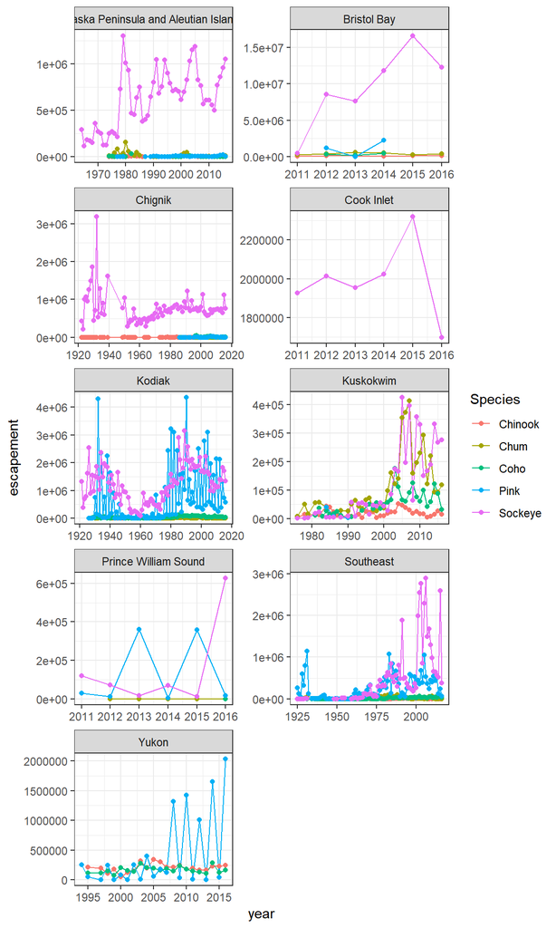

```r
plot_name<-ggplot(annual_esc, aes(x = year, y = escapement, color = Species)) +
  geom_line() +
  geom_point() +
  facet_wrap(~SASAP.Region, scales = "free", ncol = 2) +
  theme_bw()

plot_name
```

```r
ggsave("figures/region_escapement.png",
       plot = plot_name,
       height = 10,
       width = 8,
       units = "in")
```

```r
write.csv(annual_esc,
          "derived_data/annual_escapement.csv",
          row.names = F)
```

# Interactive Map!

Make a map using leaflet

- find unique locations with lat/long values

```r
locations <- esc %>%
  distinct(Location, Latitude, Longitude) %>%
  drop_na()

datatable(locations)
```

|  | Location | Latitude | Longitude |
| --- | --- | --- | --- |
| 1 | Akalura Creek | 57.1641 | -154.2287 |
| 4 | Anvik River | 62.7 | -160.2 |
| 6 | Ayakulik River | 57.1956 | -154.529 |
| 7 | Bear Creek | 56.0389 | -160.2734 |
| 8 | Bear River | 56.0389 | -160.2734 |
| 9 | Big Bay Creek | 58.5426 | -152.5683 |
| 10 | Big Kitoi Creek | 58.1915 | -152.3754 |
| 12 | Black Lake | 56.392 | -158.937 |
| 13 | Buskin River | 57.7768 | -152.5372 |
| 14 | Chelatna Lake | 62.4731 | -151.4545 |

[output cut: 58 more lines]

```r
leaflet(locations) %>%
  addTiles() %>%
  addMarkers(~ Longitude, ~ Latitude, popup = ~Location)
```

[interactive chart not shown]